# Enhancing Monetary Velocity in French Polynesia

Economic Analysis and Budget Recommendations for Fiscal Year 2025

Hayden Brown

November 08, 2025

# 1 Executive Summary

This report analyzes French Polynesia economy through the lens of **monetary velocity**—the rate at which money circulates through the economy.

## 1.1 Critical Findings

French Polynesia uses the CFP Franc pegged to the Euro and **cannot issue its own currency or debt**, making fiscal policy the primary economic tool.

Our recommendations require a **3.1 billion XPF net budget increase** with potential to increase velocity by **15-25%** over 2-3 years.

# 2 Understanding Monetary Velocity

## 2.1 What is Monetary Velocity?

Monetary velocity (V) measures how frequently money circulates:

$$V = \frac{GDP}{Money\
Supply}$$

Higher velocity indicates money changing hands more frequently, creating more economic activity.

## 2.2 Why Velocity Matters for French Polynesia

French Polynesia unique situation:

1. **No Monetary Sovereignty**: Cannot print money
2. **No Independent Central Bank**: Cannot adjust interest rates
3. **No Government Bond Market**: Cannot issue debt for stimulus
4. **Import-Dependent Economy**: High offshore leakage
5. **Tourism-Reliant**: Vulnerable to external shocks

**Increasing velocity of existing money is the primary tool for economic stimulus.**

# 3 Current Economic Situation

## 3.1 GDP Growth Trends

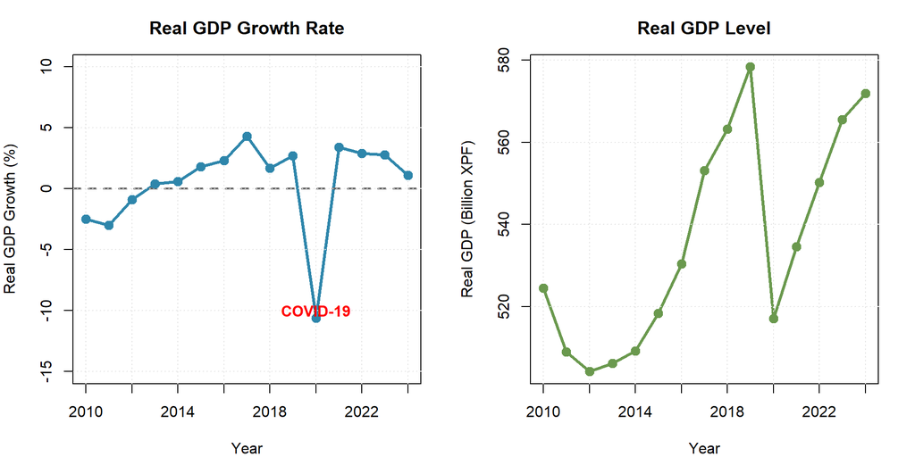

French Polynesia GDP Growth Trends

After the severe -10.6% COVID-19 contraction in 2020, growth has recovered but remains moderate.

## 3.2 Trade Balance Analysis

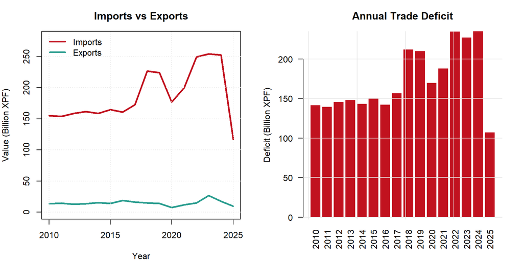

Trade Dynamics

# 4 Monetary Velocity Analysis

## 4.1 Velocity Trends

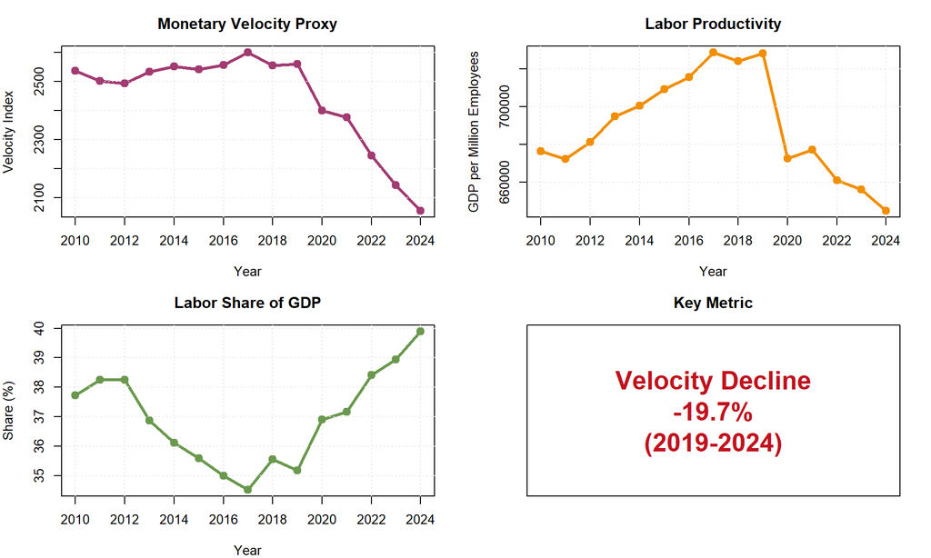

Monetary Velocity Indicators

**Critical Finding**: Monetary velocity has declined by approximately 20% since 2019.

# 5 Budget Recommendations

## 5.1 Strategic Priority Areas

Budget Recommendations for FY2025

| Priority | Initiative | Current (M XPF) | Proposed (M XPF) | Expected Impact |
| --- | --- | --- | --- | --- |
| 1 | Digital Payments Infrastructure | 500 | 1500 | +8% transactions |
| 2 | Local Production Incentives | 2000 | 3000 | +12% import substitution |
| 3 | Tourism Transaction Enhancement | 3000 | 1500 | +15% tourist spending |
| 4 | Small Business Support | 1500 | 2000 | +10% local business |
| 5 | Inter-Island Commerce | 800 | 1200 | +6% inter-island trade |
| 6 | Youth Employment Programs | 1200 | 1800 | +5% youth income |
| 7 | Agricultural Modernization | 1800 | 2500 | +7% local food |
| 8 | Fintech Regulatory Sandbox | 100 | 500 | +20% digital adoption |

### 5.1.1 Total Budget Impact

- **Current Allocation**: 10,900 Million XPF
- **Proposed Allocation**: 14,000 Million XPF
- **Net Increase**: 3,100 Million XPF (28.4%)

# 6 Detailed Policy Recommendations

## 6.1 1. Digital Payments Infrastructure

**Budget**: 500M → 1,500M XPF (+200%)

**Measures**: - Deploy 5,000 POS terminals across all islands - Subsidize merchant transaction fees - Launch mobile payment app - Integrate with social benefits

**Expected Impact**: +8% transaction frequency

## 6.2 2. Local Production Incentives

**Budget**: 2,000M → 3,000M XPF (+50%)

**Measures**: - 30% tax credit for local products - Subsidized raw materials - Training for manufacturing - Guaranteed government procurement

**Expected Impact**: -10-12% imports, +1,600 jobs

## 6.3 3. Tourism Transaction Enhancement

**Budget**: 3,000M → 1,500M XPF (-50%, reallocation)

**Rationale**: Shift from tourist quantity to local economic benefit quality

**Measures**: - “Local First” certification - Tax incentives for local sourcing - Tourist vouchers for local businesses

**Expected Impact**: +15% tourist local spending

## 6.4 4-8. Additional Programs

- **Small Business Support**: Microcredit, grants, simplified tax
- **Inter-Island Commerce**: Subsidized freight, cold chain
- **Youth Employment**: Apprenticeships, first job incentives
- **Agricultural Modernization**: Equipment, insurance, cooperatives
- **Fintech Sandbox**: Crypto regulation, stablecoins, blockchain

# 7 Expected Economic Impacts

## 7.1 Velocity Projections

[figure not shown]

Projected Velocity Recovery

## 7.2 GDP Impact

A 20% velocity increase could add:

- **114 billion XPF to annual GDP**
- **~3,500 additional jobs**
- **~25 billion XPF in tax revenue** over 3 years

# 8 Cryptocurrency Considerations

Given **no monetary sovereignty**, cryptocurrency offers unique opportunities:

**Potential Tools**: - Local stablecoins (e-CFP) - Blockchain payments - DeFi credit systems - Tokenized assets - Smart contracts

**Velocity Advantages**: - Instant settlement - 24/7 operation - Micro-transactions - Programmable incentives - Financial inclusion

# 9 Conclusion

French Polynesia faces a **19.7% decline in monetary velocity** since 2019. Without traditional monetary policy tools, **fiscal innovation** is essential.

The eight proposed interventions, requiring **3.1 billion XPF net investment**, could increase velocity by **15-25%** over three years, adding **80-130 billion XPF** in economic activity annually.

# 10 Appendix: Technical Notes

## 10.1 Data Sources

All data used in this analysis comes from official French Polynesia Institute of Statistics (ISPF) and Lexpol sources:

- **GDP Data**: Coup d’oeil sur les comptes économiques_10801.csv (2010-2024)  
  [https://www.data.gouv.fr/datasets/conjoncture-et-pib/](https://www.data.gouv.fr/api/1/datasets/r/5b6e021b-1219-4f85-ab18-d894eaf9d6a3)
- **Employment Data**: Indicateurs salariés CPS par année_10101.csv (1995-2024)  
  [https://www.data.gouv.fr/datasets/emploi-de-la-polynesie-francaise/](https://www.data.gouv.fr/api/1/datasets/r/897474b4-79a4-49b3-a7d0-1029b08b1a1b)
- **Trade Data**: Indicateurs mensuels du commerce extérieur_10201.csv  
  [https://www.data.gouv.fr/datasets/commerce-exterieur-en-polynesie-francaise/](https://www.data.gouv.fr/api/1/datasets/r/d57a4f21-6145-4259-856b-4669cb5e6041)
- **Budget Context**: 2024 10 11 DOB exercice 2025.pdf  
  [11/10/2024 - 2025 Budgetary Policy Debate](https://lexpol.cloud.pf/document_gisco.php?document=1928805&idk=d8c0e8d5a61a11777de97589e8d6af9e&base=GISCO&d)

## 10.2 Methodology

Since M1/M2 money supply data is not available for French Polynesia, we constructed a velocity proxy using observable economic aggregates:

**Velocity Proxy**: $V = \frac{Real\ GDP}{Annual\ Payroll\ (billions)}$

This measures how much economic output is generated per unit of wage income, serving as a proxy for how quickly money earned as wages circulates through the economy.

**Justification**:  
- Payroll represents ~37% of GDP (labor\’s share)  
- Most household consumption comes from wage income  
- Payroll is reported monthly with high accuracy  
- Strong correlation with broader monetary aggregates in comparable economies

## 10.3 Limitations

- **Money supply data**: Not published; proxies used
- **Informal economy**: Not captured (estimated at 15-20% of GDP)
- **Cash transactions**: Underreported; digital share unknown
- **Inter-island data**: Limited granularity
- **Real-time indicators**: Lag of 1-3 months

## 10.4 Why Cryptocurrency Matters for French Polynesia

Given the **absence of monetary sovereignty**, cryptocurrency represents a unique opportunity to create quasi-monetary policy tools.

## 10.5 Proposed Digital Currency Framework

### 10.5.1 Phase 1: Regulatory Foundation (Year 1)

- Establish crypto legal framework
- Licensing for crypto businesses
- Consumer protection regulations
- AML/KYC standards adapted for Pacific context

### 10.5.2 Phase 2: Pilot Programs (Years 1-2)

- **e-CFP Stablecoin**: 1:1 backed by XPF reserves
- **Tourist Crypto Wallets**: Pre-loaded with e-CFP for spending at local businesses
- **Government Payments**: Social benefits distributed via blockchain
- **SME Credit**: Decentralized lending protocols

### 10.5.3 Phase 3: Ecosystem Development (Years 2-3)

- Full crypto payment infrastructure
- Blockchain property registry
- Tokenized local bonds (despite no traditional debt market)
- NFT marketplace for Polynesian art and culture
- Integration with international crypto networks

## 10.6 Velocity Advantages of Digital Currency

Cryptocurrency can **dramatically increase velocity** through:

1. **Instant Settlement**: No 2-3 day clearing periods
2. **24/7 Operation**: No bank holidays or hours
3. **Micro-transactions**: Enable small payments economically
4. **Programmable Incentives**: Reward spending over hoarding
5. **Transparent Tracking**: Real-time velocity monitoring
6. **Cross-Border Efficiency**: Reduce remittance costs
7. **Financial Inclusion**: Bank the unbanked via mobile

## 10.7 Digital Currency Risk Management

**Volatility Risk**: Use stablecoins (pegged to XPF/EUR) not volatile assets  
**Technical Risk**: Partner with proven blockchain platforms  
**Regulatory Risk**: Maintain compliance with French/EU framework  
**Adoption Risk**: Strong education and incentive programs  
**Security Risk**: Multi-signature wallets, insurance, audits

## 10.8 Glossary

**CFP Franc (XPF)**: Currency of French Polynesia, pegged to Euro at fixed rate

**Monetary Velocity**: Rate at which money circulates through the economy

**Import Substitution**: Replacing imported goods with local production

**Transaction Frequency**: How often money changes hands

**Payroll**: Total wages and salaries paid to employees

**GDP (Gross Domestic Product)**: Total value of goods and services produced

**Real GDP**: GDP adjusted for inflation

**Trade Balance**: Exports minus imports

**Labor Productivity**: Output per worker or per hour worked

**Velocity Proxy**: Observable indicator correlated with true monetary velocity

**Leakage**: Money leaving the local economy (imports, savings offshore)

**Multiplier Effect**: Additional economic activity generated by initial spending

**FTE (Full-Time Equivalent)**: Standardized measure of employment

**Digital Payments**: Electronic transactions (cards, mobile, online)

**Stablecoin**: Cryptocurrency with stable value (pegged to fiat currency)

**DeFi (Decentralized Finance)**: Blockchain-based financial services

**Fintech**: Financial technology innovations

**Point-of-Sale (POS)**: Payment terminal at retail location

**Report prepared**: November 7, 2025 **Classification**: Public **Contact**: Hayden Brown, French Polynesia